# Data Visualization using `ggplot()`

## Choosing Effective Data Visualizations

Data visualizations have become commonplace in our society as data collection has increased. There are many types of visualizations available to us- scatter plots, box plots, mosaic plots, and word clouds, just to name a few. How can we decide what type of visualization is appropriate for a dataset? The answer depends largely on the type of data that you are working with. Recall that a **numerical** variable is a variable which is obtained through measurement, and for which comparing values of the variable makes sense (think – would an average of these values be meaningful?). Examples of numerical variables include heights, distances, temperatures, budget sizes, etc. A **categorical** variable is a variable which sorts values into “bins”. Examples of categorical variables include a person’s sex, the answer to a yes or no question, a student’s grade level, etc. Whether to consider a variable to be numerical or categorical is not always obvious and may depend upon the context of the dataset.

### Single Numerical Variable

A single numerical variable can be visualized using a histogram, a box plot, or a violin plot. Let’s consider a the bill length `bill_length_mm` of Gentoo penguins. A **histogram** takes the various bill lengths of the penguins (between 40.9 mm and 59.6 mm in this case), and groups them together into bins of equal length. Then, a bar is drawn over each bin whose height reflects the number (or proportion) of penguins whose bill length lies within the bin. The `bins =` argument in the `geom_histogram()` layer controls the number of bins that are created. Notice that the `bins` argument falls outside of the `aes()` parentheses because its value is not being inherited from a column in our dataset.

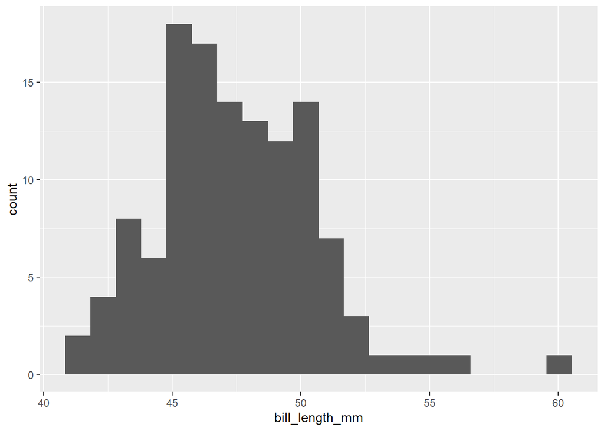

```r
penguins %>%
  filter(!is.na(bill_length_mm),
         species == "Gentoo") %>%
  ggplot() +
  geom_histogram(aes(x = bill_length_mm), bins = 20)
```

Often, we would like to see how close a histogram is to a Normal distribution (the bell-shaped curve). To do this, we will add a `stat_function` layer which draws a Normal curve with mean and standard deviation equal to the mean and standard deviation of the data set. In this case, we will let the y-coordinate be `..density..` which measures the proportion of penguins which lie in each bin, rather than the number of penguins. The arguments of the `stat_function()` layer are `fun =`, which tells R what type of distribution to draw and `args =`, which provides R with the mean and standard deviation of the distribution.

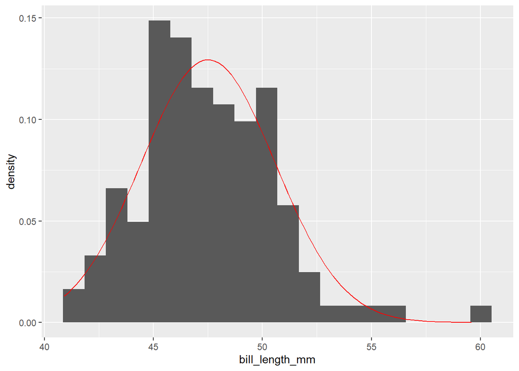

```r
penguins %>%
  filter(!is.na(bill_length_mm),
         species == "Gentoo") %>%
  ggplot() +
  geom_histogram(aes(x = bill_length_mm, y = ..density..), bins = 20) +
  stat_function(fun = dnorm,
                args = list(mean = penguins %>%
                              filter(!is.na(bill_length_mm),
                                     species == "Gentoo") %>%
                              pull(bill_length_mm) %>%
                              mean(),
                            sd = penguins %>%
                              filter(!is.na(bill_length_mm),
                                     species == "Gentoo") %>%
                              pull(bill_length_mm) %>%
                              sd()),
                color = "red")
```

A box plot is helpful when your goal is to visualize the “center” of the data (using the median) and to get a sense of how spread out the data is.

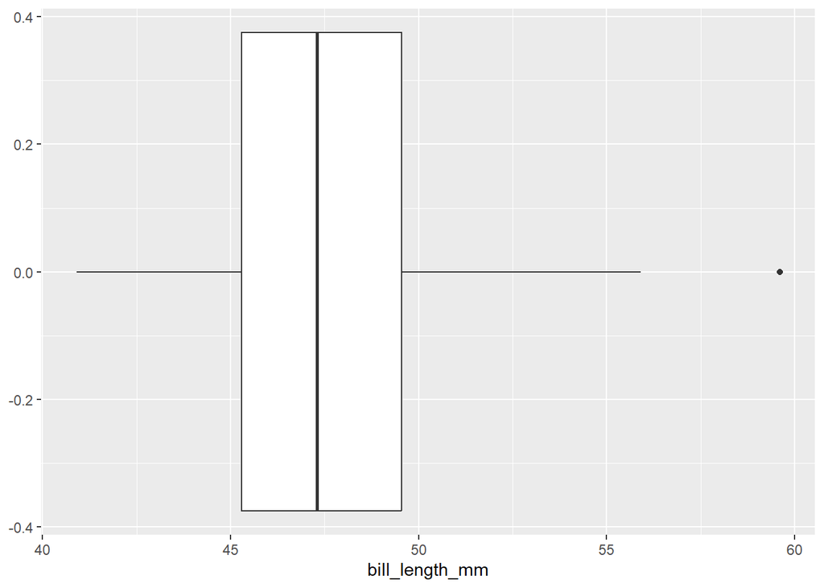

```r
penguins %>%
  filter(!is.na(bill_length_mm),
         species == "Gentoo") %>%
  ggplot() +
  geom_boxplot(aes(x = bill_length_mm))
```

The line in the interior of the white box corresponds to the median value of the bill length variable, which is 47.3 mm in this example. The length of the white box is the *interquartile range*. All values between the 25th and 75 percentiles of the data lie in this range. The lines (“whiskers”) coming from the interquartile range extend out to either i) the minimum or maximum value in the data, or ii) to 1.5 times the interquartile range. Any values that extend beyond 1.5 interquartile ranges away from the median are marked with dots.

You’ve probably already noticed some advantages to the `ggplot()` framework. Creating new types of plots are easy because the syntax is consistent. Switching from a histogram to a box plot is as simple as changing the type of layer being added to the plot!